# I like to move it, move it: Keeping lemurs happy with R

Dr. Ludmilla Figueiredo

Here, we are going to use the [Lemurs](https://github.com/rfordatascience/tidytuesday/blob/master/data/2021/2021-08-24/readme.md) data set provided by the [TidyTuesday project](https://github.com/rfordatascience/tidytuesday) to illustrate:

- data processing with packages from the [R Tidyverse](https://www.tidyverse.org)
- document your with RMarkdown and the [minimal set up for reproducible research](https://github.com/ludmillafigueiredo/computational_notebooks) I propose for beginners

# Packages and basic set up

## R packages

In this analysis, we will rely heavily on packages from the [Tidyverse](https://www.tidyverse.org). This is a collection of packages that were collectively designed specifically for data science. This means that these packages share data structures, function syntax, and can be easily combined in a slick, yet comprehensible workflow.

```r
library(tidyverse)
library(lubridate) # easy manipulation of date objects
```

More specifically, we will work with the following packages:

- `readr`: functions to easily, yet reliably read in rectangular data (e.g. csv, tsv) containing multiple data types (e.g. numeric, logical). By reliably, I mean that it can recognize errors in that table formatting that require checking by the user (e.g. the occurrence of numeric values in a seemingly logical column).
- `tidyr`: functions to create and manipulate “tidy data”, i.e., data where each column is a variable, each row is an observation, and each is unique. The other functions in `tidyverse` are optimized to work with this type of data.
- `dplyr`: functions for data manipulation (e.g. filtering, summarizing). One of features that make this package particularly good is the fact that functions are names as verbs, indicating the type of data transformation that it does. This makes reading the code considerably easy.
- `stringr`: functions for string manipulation, considering that this is not one of base R strengths.
- `gglot2`: functions to code graphs following the (“Grammar of Graphics”)[https://cfss.uchicago.edu/notes/grammar-of-graphics/]. Simply put, the grammar of graphics is a system of rules that allows coding data into visual elements - reading the article above and other precise definitions is highly recommendable, though.

## Project set up

The files in this project are organized as such:

```markdown
data_crunch_wue
|--README.md
|--lemurs.Rmd
|--figures
|--results
|  |--data
|  |  |--raw
|  |  |--processed
|  |--figures
|  |--tables
|  |--scripts
```

This file structure adapts the [minimal set up](https://github.com/ludmillafigueiredo/computational_notebooks) I propose for scientific computational projects. The idea is organizing the project around the `.Rmd` file (the `.html` version of which you are reading right now). By combining descriptive text code and results of the analysis, this “computational notebook” facilitates communication and reproducibility of the work it reports. As part of this set up, inputs and outputs can be accessed with relative paths:

```r
raw_dir <- file.path("results", "data", "raw")
processed_dir <- file.path("results", "data", "processed")
scripts_dir <- file.path("reults", "scripts")
figures_dir <- file.path("results", "figures")
tables_dir <- file.path("results", "tables")
```

# Original data

As shown in the [dataset page](https://github.com/rfordatascience/tidytuesday/blob/master/data/2021/2021-08-24/readme.md), the original data can be downloaded the git repository:

```r
lemurs_df <- readr::read_csv('https://raw.githubusercontent.com/rfordatascience/tidytuesday/master/data/2021/2021-08-24/lemur_data.csv')
```

Already at loading, it seems we come across a parsing error: `read_csv` identified the column `age_of_living_y` as containing characters of type `logical` (it cites the expected values as ``1/0/T/F/TRUE/FALSE`), but it seems that at line 1324, the value is a `double`. The simplest reason why this error can occur is that, with default settings, the `read_csv` function identifies the types of objects (`character`, `logical`, etc.) in each column of the data frame based on the first 1000 rows. We can verify whether the contents of the first 1000 rows:

```r
unique(lemurs_df[1:1000, "age_of_living_y"])
```

```
## # A tibble: 1 x 1
##   age_of_living_y
##   <lgl>
## 1 NA
```

Thus, we see that missing data in these rows lead to the issue with its identification. We can fix it by explicitly identifying the types of objects in the columns of the data frame. Before we do this, however, let’s verify that `age_of_living_y` was the only column that raised an issue, with the `problems` attribute of objects read with the `read_*` functions from the `readr` package. This attribute stores parsing problems in a data frame containing the `row` and `col` where `expected` and `actual` values differ.

```r
unique(problems(lemurs_df)$col)
```

```
## [1] "age_of_living_y"
```

When specifying the columns types, it’s all or nothing: we either identify all of them, or none at all. With 54 columns, this would be a lot, but this is where the **magic** starts: the `spec()` function lists all column types, and we just need to fixed the ones that were read in wrong.

```r
spec(lemurs_df)
lemurs_rawdf <- readr::read_csv('https://raw.githubusercontent.com/rfordatascience/tidytuesday/master/data/2021/2021-08-24/lemur_data.csv',
                          col_types = cols(
                            .default = col_double(),
                            taxon = col_character(),
                            dlc_id = col_character(),
                            hybrid = col_character(),
                            sex = col_character(),
                            name = col_character(),
                            current_resident = col_character(),
                            stud_book = col_character(),
                            dob = col_date(format = ""),
                            birth_month = col_double(),
                            estimated_dob = col_character(),
                            birth_type = col_character(),
                            birth_institution = col_character(),
                            estimated_concep = col_date(format = ""),
                            dam_id = col_character(),
                            dam_name = col_character(),
                            dam_taxon = col_character(),
                            dam_dob = col_date(format = ""),
                            dam_age_at_concep_y = col_double(),
                            sire_id = col_character(),
                            sire_name = col_character(),
                            sire_taxon = col_character(),
                            sire_dob = col_date(format = ""),
                            dod = col_date(format = ""),
                            age_of_living_y = col_double(), ## the column that was tyoed wrong by default
                            dob_estimated = col_character(),
                            weight_date = col_date(format = ""),
                            age_category = col_character(),
                            preg_status = col_character(),
                            concep_date_if_preg = col_date(format = ""),
                            infant_dob_if_preg = col_date(format = "")
                            )
)
```

Let’s also load a data frame with the species full names and abbreviations, to use later for more understandable graphs and tables:

```r
lemurs_sppnames_df <- readr::read_csv("https://raw.githubusercontent.com/ludmillafigueiredo/computational_notebooks/master/examples/datastudy_r/results/data/raw/lemurs_sppnames.csv")
```

## Pre-processing

We have a couple of things to work on in the original table, to make it originally more digestible:

1. The individuals names are capitalized, but it can be annoying to read. Let’s capitalize the first letter, only.

```r
lemurs_smallts <- dplyr::mutate_at(lemurs_rawdf, vars(name, dam_name, sire_name), stringr::str_to_title)
```

2. One of the most notable features of this data set is that it started being collected in the 1960’s. However, at first glance, there is no clear column stating the date at which the data was collected (I myself expected it to be one of the first columns). After reading the data description in the original repo, we learn that the `weight_date` and `month_of_weight` variables report the full date and the month when the weight was measured, respectively. It would be good to have those two easily accessible.

```r
lemurs_smallts <- dplyr::mutate(lemurs_smallts, year = lubridate::year(weight_date))
lemurs_smallts <- dplyr::rename(lemurs_smallts, month = month_of_weight)
```

```r
lemurs_smallts <- dplyr::select(lemurs_smallts,
                                c(year, month, ## time variables
                                  taxon, dlc_id, ## id variables
                                  hybrid, sex, name, birth_month, litter_size, concep_month, ## birth variables
                                  dam_id, dam_name, dam_taxon, ## name of mother
                                  sire_id, sire_name, sire_taxon, ## name of father
                                  age_at_death_y, age_of_living_y, age_last_verified_y, ## age variables
                                  age_max_live_or_dead_y, age_at_wt_y, age_category, ## age variables
                                  weight_g, avg_daily_wt_change_g, ## weight variables
                                  preg_status,
                                  n_known_offspring, infant_lit_sz_if_preg))

lemurs_smallts <- dplyr::rename(lemurs_smallts,
                                weight = weight_g,
                                avg_d_wt_chg = avg_daily_wt_change_g,
                                n_offspring = n_known_offspring)
```

However, having that many iterations redefining the same object (the `lemurs_smallts` in this case) is not good practice, because if you forget one of them for some reason, it can lead to errors down the line (e.g. you do transformations on one of the “intermediate” stages). Having multiple objects is also not great, because one would have to name them, and it would be a waste of creativity on temporary files. With that in mind, let’s try some *magic*: We will put all the transformations together in a **pipeline**, where the transformations are chained in a readable form, any only one data frame is created at the end:

```r
lemurs_smallts <- lemurs_rawdf %>%
  # 1. capitalizing the first letter, only
  dplyr::mutate_at(vars(name, dam_name, sire_name), stringr::str_to_title) %>%
  # 2. extract the year of the measure, and give a simpler name to the column containing the
  dplyr::mutate(year = lubridate::year(weight_date)) %>%
  dplyr::rename(month = month_of_weight) %>%
  # 3. select the most relevant
  dplyr::select(c(year, month, ## time variables
                  taxon, dlc_id, ## id variables
                  hybrid, sex, name, birth_month, litter_size, concep_month, ## birth variables
                  dam_id, dam_name, dam_taxon, ## name of mother
                  sire_id, sire_name, sire_taxon, ## name of father
                  age_at_death_y, age_of_living_y, age_last_verified_y, ## age variables
                  age_max_live_or_dead_y, age_at_wt_y, age_category, ## age variables
                  weight_g, avg_daily_wt_change_g, ## weight variables
                  preg_status,
                  n_known_offspring, infant_lit_sz_if_preg)) %>%
  ## simplify the names
  dplyr::rename(weight = weight_g,
                avg_d_wt_chg = avg_daily_wt_change_g,
                n_offspring = n_known_offspring)
```

# Exploring the data

## Reproduction

If we are trying to protect a species, reproduction is one of the most important aspects to understand. With the DLC lemur data, we can estimate fertility rates, reproductive seasons, and the relationship between age, sizes and offspring production.

### Fertility rates per taxon

Let’s have a look at the fertility rates of the species we are trying to save:

```r
fertiilty_df <- lemurs_smallts %>%
  dplyr::right_join(lemurs_sppnames_df,., by = "taxon") %>% ## add species names, so we have a complete table
  dplyr::filter(!is.na(infant_lit_sz_if_preg)) %>% ## filter the animals for which this information was available
  dplyr::group_by(dlc_id, species) %>%
  dplyr::summarize(inflt_mean_ind = mean(infant_lit_sz_if_preg)) %>%
  ungroup() %>%
  dplyr::group_by(species) %>%
  dplyr::summarize(inflt_mean = mean(inflt_mean_ind),
                   inflt_sd = sd(inflt_mean_ind),
                   n = n()) %>%
  dplyr::rename(Species = species,
                "Infant litter size (mean)" = inflt_mean,
                "Infant litter size (sd)" = inflt_sd)
```

We can save this table

```r
readr::write_csv(fertiilty_df, file = file.path(tables_dir, "fertility_rates.csv"))
```

Or have it nicely displayed in our html file:

```r
fertiilty_df %>%
   kableExtra::kbl(caption = "Fertility rates (mean +- sd) of the species housed at the Duke Lemur Center, in North Carolina, USA.")%>%
  kableExtra::kable_styling(c("striped", "hover")) %>%
  kableExtra::scroll_box(width = "100%", height = "300px")
```

Fertility rates (mean +- sd) of the species housed at the Duke Lemur Center, in North Carolina, USA.

| Species | Infant litter size (mean) | Infant litter size (sd) | n |
| --- | --- | --- | --- |
| Cheirogaleus medius | 1.912775 | 0.8543182 | 13 |
| Daubentonia madagascariensis | 1.000000 | 0.0000000 | 7 |
| Eulemur albifrons | 1.000000 | NA | 1 |
| Eulemur collaris | 1.000000 | 0.0000000 | 7 |
| Eulemur coronatus | 1.108333 | 0.2486072 | 10 |
| Eulemur Eulemur | 1.000000 | 0.0000000 | 5 |
| Eulemur flavifrons | 1.051079 | 0.1270108 | 13 |
| Eulemur fulvus | 1.000000 | 0.0000000 | 4 |
| Eulemur macaco | 1.125000 | 0.3535534 | 8 |
| Eulemur mongoz | 1.010417 | 0.0416667 | 16 |
| Eulemur rubriventer | 1.080000 | 0.1788854 | 5 |
| Eulemur rufus | 1.145833 | 0.2736801 | 8 |
| Eulemur sanfordi | 1.000000 | NA | 1 |
| Galago moholi | 1.357143 | 0.4738035 | 4 |
| Hapalemur griseus griseus | 1.123457 | 0.2055889 | 9 |
| Lemur catta | 1.330122 | 0.3794544 | 32 |
| Loris tardigradus | 1.000000 | 0.0000000 | 10 |
| Mircocebus murinus | 2.326840 | 0.8419061 | 22 |
| Mirza coquereli | 1.733333 | 0.4346135 | 5 |
| Nycticebus coucang | 1.000000 | 0.0000000 | 14 |
| Nycticebus pygmaeus | 1.728566 | 0.2791717 | 7 |
| Otolemur garnettii garnettii | 1.136842 | 0.3336840 | 19 |
| Perodicticus potto | 1.000000 | 0.0000000 | 3 |
| Propithecus coquereli | 1.000000 | 0.0000000 | 22 |
| Varecia rubra | 1.998291 | 0.7132938 | 13 |
| Varecia Varecia | 2.000000 | 0.0000000 | 2 |
| Varecia variegata variegata | 1.959375 | 0.7996520 | 16 |

**Question:** one could argue that this summary is hiding some valuable information. Any guesses?

## Seasonality of species

Many species of lemurs are seasonal breeders, meaning that are specific times of the year when animal will look for partners and reproduce. Let’s see if we can detect it in data.

First, I know that the data contains the dates in numeric form, but it would be nice to have the names of each month in data, for later plotting Remember, we are obeying the Grammar of Graphics, so we cannot simply paste tags with the names of months later on.

So, we start with a simple data frame with the relevant information: individuals id, taxon, and month of birth.

```r
births_df <- lemurs_smallts %>%
  dplyr::select(dlc_id, taxon, birth_month) %>%
  dplyr::filter(!is.na(birth_month)) %>%
  dplyr::mutate_at(vars(birth_month),
                   lubridate::month, label = TRUE,
                   locale = Sys.getlocale(category = "LC_CTYPE")) %>% ## id months
  dplyr::right_join(lemurs_sppnames_df,., by = "taxon") %>% ## id species
  dplyr::arrange(taxon, birth_month)
```

Now, let’s count the number of births that happened per species, per month:

```r
birth_season_countdf <- births_df %>%
  unique() %>%
  dplyr::group_by(species, common_name, taxon, birth_month) %>%
  dplyr::summarize(n_births = n()) %>%
  ungroup() %>%
  dplyr::arrange(species, common_name, taxon, birth_month)
```

Let’s say we would like to plot this:

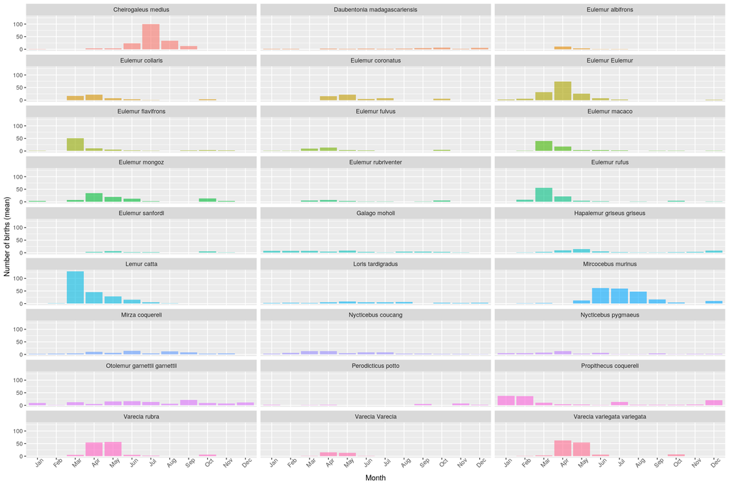

```r
birth_season_countdf  %>%
  ggplot(aes(x = birth_month, y = n_births, fill = species)) +
  geom_bar(alpha=0.6, stat = "identity") +
  facet_wrap(~species, ncol = 3) +
  labs(x = "Month", y = "Number of births (mean)") +
  theme(legend.position = "none",
        axis.text.x = element_text(angle = 45))
```

I can define specific aesthetic values to be applied to my plot:

```r
source("results/scripts/custom_aesthetics.R")
```

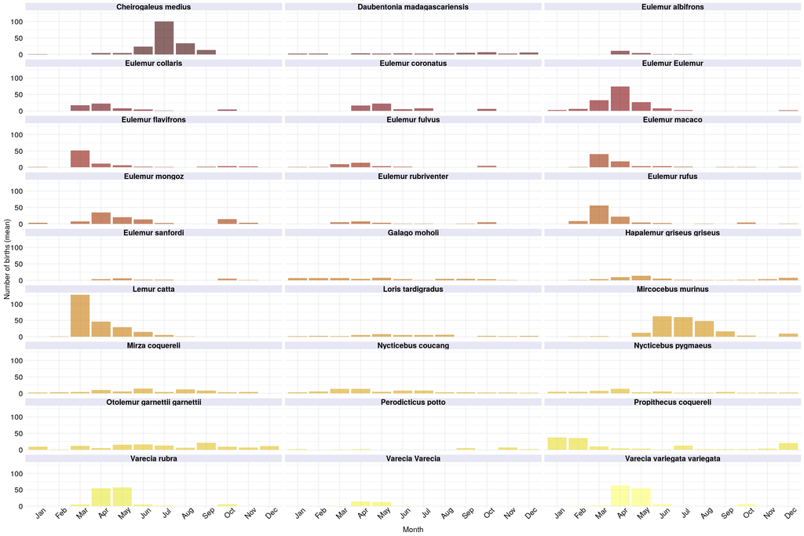

```r
birth_season_countdf  %>%
  ggplot(aes(x = birth_month, y = n_births, fill = species)) +
  geom_bar(alpha=0.6, stat = "identity") +
  theme_lemurs() +
  facet_wrap(~species, ncol = 3) +
  labs(x = "Month", y = "Number of births (mean)") +
  theme(legend.position = "none",
        axis.text.x = element_text(angle = 45))
```

**Challenge:** there is a mistake in this summary. What is it?

**Question:** If we were talking to a larger audience, we could include the common names of the species in this graph, how would we go about ?

## Offspring production

```r
offspring_df <- lemurs_smallts %>%
  dplyr::right_join(lemurs_sppnames_df,., by = "taxon") %>% ## id species
  dplyr::select(year, month, species, taxon, dlc_id, sex,
                litter_size, ## size of litter it was born into
                age_at_wt_y, weight, ## age and weight
                preg_status, ## pregnancy status
                n_offspring, ## total number of offspring produced until that day
                infant_lit_sz_if_preg) ## size of litter, if pregnant
```

### Individual female weight and offspring production

Let’s see if we can find some relationship between pregnant female weight and the size of the litter it is carrying.

First, let’s look into species separately:

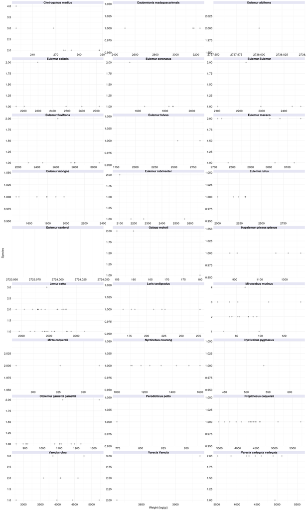

```r
offspring_df  %>%
  ## filter only the pregnant females
  dplyr::filter(preg_status == "P") %>%
  ## get their last measurement  while pregnant
  dplyr::group_by(dlc_id) %>%
  dplyr::filter(age_at_wt_y == max(age_at_wt_y)) %>%
  ungroup() %>%
  ggplot(aes(x = weight, y = litter_size))+
  geom_point(alpha = 0.2) +
  facet_wrap(~species, ncol = 3, scales = "free") +
  labs(x = "Weight (log(g))", y = "Species", size = "Infant litter size") +
  theme_lemurs()
```

This was not very informative, but let’s see if we can have a summarized graph, at least

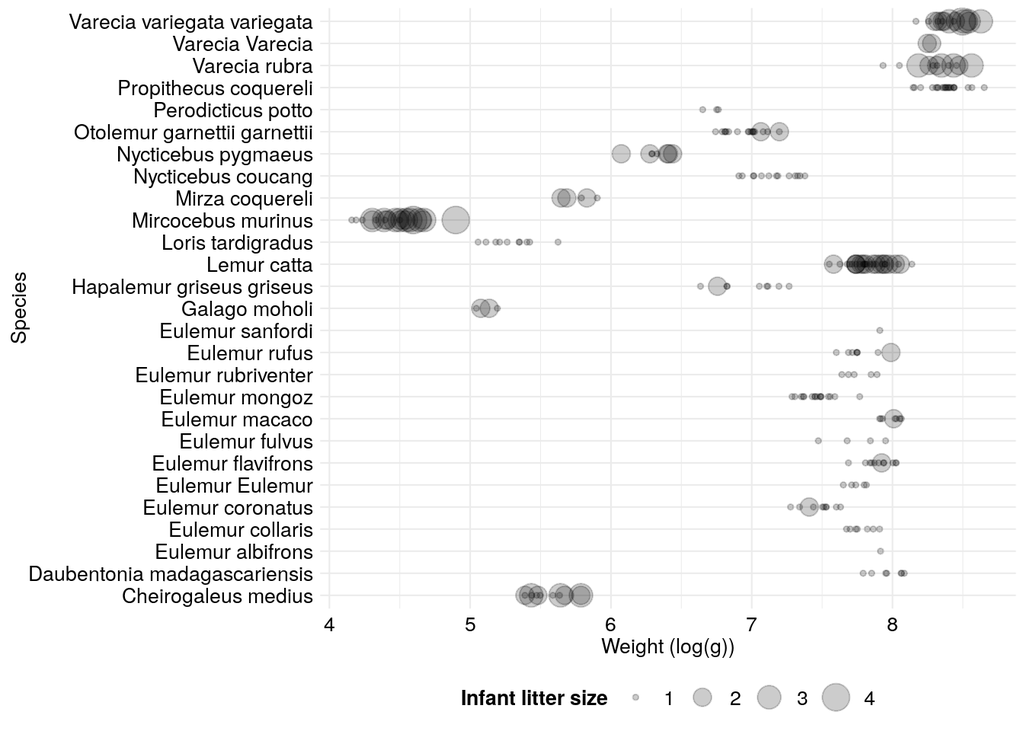

```r
offspring_df  %>%
  ## filter only the pregnant females
  dplyr::filter(preg_status == "P") %>%
  ## get their last measurement  while pregnant
  dplyr::group_by(dlc_id) %>%
  dplyr::filter(age_at_wt_y == max(age_at_wt_y)) %>%
  ungroup() %>%
  ggplot(aes(x = log(weight), y = species))+
  geom_point(aes(size = infant_lit_sz_if_preg), alpha = 0.2) +
  labs(x = "Weight (log(g))", y = "Species", size = "Infant litter size") +
  theme_lemurs()
```

### Individual weight and litter size Is individual’s weight affected by the size of the litter it was in? Get individual’s weight at its younger age and plot it against against the litter it came from (separate males and females differently)

```r
litterweight_df <- offspring_df %>%
  dplyr::group_by(dlc_id) %>%
  dplyr::filter(age_at_wt_y == min(age_at_wt_y)) %>% ## filter for the younger age of a single individual
  ungroup()
```

#### Mean infant weight

```r
litterweight_df %>%
  dplyr::group_by(species) %>%
  dplyr::summarize(weight_mean = mean(weight),
                   weight_sd = sd(weight)) %>%
  dplyr::arrange(weight_mean)  %>%
   kableExtra::kbl(caption = "Infant size (mean +- sd) of the species housed at the Duke Lemur Center, in North Carolina, USA.")%>%
  kableExtra::kable_styling(c("striped", "hover")) %>%
  kableExtra::scroll_box(width = "100%", height = "300px")
```

Infant size (mean +- sd) of the species housed at the Duke Lemur Center, in North Carolina, USA.

| species | weight_mean | weight_sd |
| --- | --- | --- |
| Mircocebus murinus | 46.55263 | 40.60969 |
| Galago moholi | 56.44510 | 65.37406 |
| Loris tardigradus | 88.04091 | 71.92052 |
| Nycticebus pygmaeus | 140.01418 | 207.20038 |
| Cheirogaleus medius | 140.57398 | 112.29466 |
| Mirza coquereli | 224.13714 | 108.32224 |
| Hapalemur griseus griseus | 300.79592 | 345.94202 |
| Daubentonia madagascariensis | 409.59273 | 779.91112 |
| Perodicticus potto | 544.68182 | 476.33900 |
| Eulemur flavifrons | 551.80286 | 815.14909 |
| Nycticebus coucang | 585.27612 | 511.38793 |
| Propithecus coquereli | 611.64595 | 1307.95988 |
| Otolemur garnettii garnettii | 624.86850 | 451.39680 |
| Eulemur rubriventer | 651.52000 | 855.25426 |
| Eulemur mongoz | 756.73619 | 696.07625 |
| Lemur catta | 849.66735 | 990.33820 |
| Eulemur coronatus | 896.58644 | 693.56773 |
| Varecia Varecia | 943.37879 | 1297.88274 |
| Eulemur Eulemur | 1014.67419 | 970.02145 |
| Eulemur rufus | 1227.22245 | 1014.64928 |
| Eulemur macaco | 1238.90137 | 1091.10120 |
| Varecia rubra | 1248.20649 | 1327.63775 |
| Eulemur collaris | 1424.04828 | 1006.32052 |
| Eulemur sanfordi | 1596.78421 | 696.43490 |
| Eulemur fulvus | 1617.04054 | 1008.32868 |
| Varecia variegata variegata | 1621.11523 | 1567.93244 |
| Eulemur albifrons | 1756.97059 | 969.45562 |

#### Mean litter size

```r
litterweight_df %>%
  dplyr::group_by(species) %>%
  dplyr::summarize(litter_mean = mean(litter_size),
                   litter_sd = sd(litter_size)) %>%
  dplyr::arrange(litter_mean)  %>%
   kableExtra::kbl(caption = "Litter size (mean +- sd) of the species housed at the Duke Lemur Center, in North Carolina, USA.")%>%
  kableExtra::kable_styling(c("striped", "hover")) %>%
  kableExtra::scroll_box(width = "100%", height = "300px")
```

Litter size (mean +- sd) of the species housed at the Duke Lemur Center, in North Carolina, USA.

| species | litter_mean | litter_sd |
| --- | --- | --- |
| Varecia Varecia | 2.333333 | 0.595119 |
| Cheirogaleus medius | NA | NA |
| Daubentonia madagascariensis | NA | NA |
| Eulemur albifrons | NA | NA |
| Eulemur collaris | NA | NA |
| Eulemur coronatus | NA | NA |
| Eulemur Eulemur | NA | NA |
| Eulemur flavifrons | NA | NA |
| Eulemur fulvus | NA | NA |
| Eulemur macaco | NA | NA |
| Eulemur mongoz | NA | NA |
| Eulemur rubriventer | NA | NA |
| Eulemur rufus | NA | NA |
| Eulemur sanfordi | NA | NA |
| Galago moholi | NA | NA |
| Hapalemur griseus griseus | NA | NA |
| Lemur catta | NA | NA |
| Loris tardigradus | NA | NA |
| Mircocebus murinus | NA | NA |
| Mirza coquereli | NA | NA |
| Nycticebus coucang | NA | NA |
| Nycticebus pygmaeus | NA | NA |
| Otolemur garnettii garnettii | NA | NA |
| Perodicticus potto | NA | NA |
| Propithecus coquereli | NA | NA |
| Varecia rubra | NA | NA |
| Varecia variegata variegata | NA | NA |

```r
litterweight_df %>%
  dplyr::group_by(species) %>%
  dplyr::summarize(litter_mean = mean(litter_size, na.rm = TRUE),
                   litter_sd = sd(litter_size, na.rm = TRUE)) %>%
  dplyr::arrange(litter_mean)  %>%
   kableExtra::kbl(caption = "Litter size (mean +- sd) of the species housed at the Duke Lemur Center, in North Carolina, USA.")%>%
  kableExtra::kable_styling(c("striped", "hover")) %>%
  kableExtra::scroll_box(width = "100%", height = "300px")
```

Litter size (mean +- sd) of the species housed at the Duke Lemur Center, in North Carolina, USA.

| species | litter_mean | litter_sd |
| --- | --- | --- |
| Daubentonia madagascariensis | 1.000000 | 0.0000000 |
| Nycticebus coucang | 1.000000 | 0.0000000 |
| Perodicticus potto | 1.000000 | 0.0000000 |
| Propithecus coquereli | 1.000000 | 0.0000000 |
| Eulemur mongoz | 1.051282 | 0.2220001 |
| Loris tardigradus | 1.057143 | 0.2355041 |
| Eulemur rubriventer | 1.100000 | 0.3077935 |
| Hapalemur griseus griseus | 1.100000 | 0.3038218 |
| Eulemur flavifrons | 1.131868 | 0.3402219 |
| Eulemur sanfordi | 1.133333 | 0.3518658 |
| Eulemur rufus | 1.151163 | 0.3603084 |
| Eulemur fulvus | 1.160000 | 0.3741657 |
| Otolemur garnettii garnettii | 1.196078 | 0.3989892 |
| Eulemur coronatus | 1.282609 | 0.4552432 |
| Eulemur Eulemur | 1.288591 | 0.4972261 |
| Eulemur collaris | 1.380000 | 0.4903144 |
| Galago moholi | 1.543478 | 0.5036102 |
| Lemur catta | 1.548673 | 0.5331858 |
| Eulemur macaco | 1.573770 | 0.4986320 |
| Eulemur albifrons | 1.642857 | 0.4972452 |
| Mirza coquereli | 1.818182 | 0.3892495 |
| Nycticebus pygmaeus | 1.918367 | 0.4931504 |
| Varecia variegata variegata | 2.314516 | 0.8101685 |
| Varecia Varecia | 2.333333 | 0.5951190 |
| Cheirogaleus medius | 2.567251 | 0.9074094 |
| Varecia rubra | 2.602837 | 0.7547888 |
| Mircocebus murinus | 2.625000 | 0.8087458 |

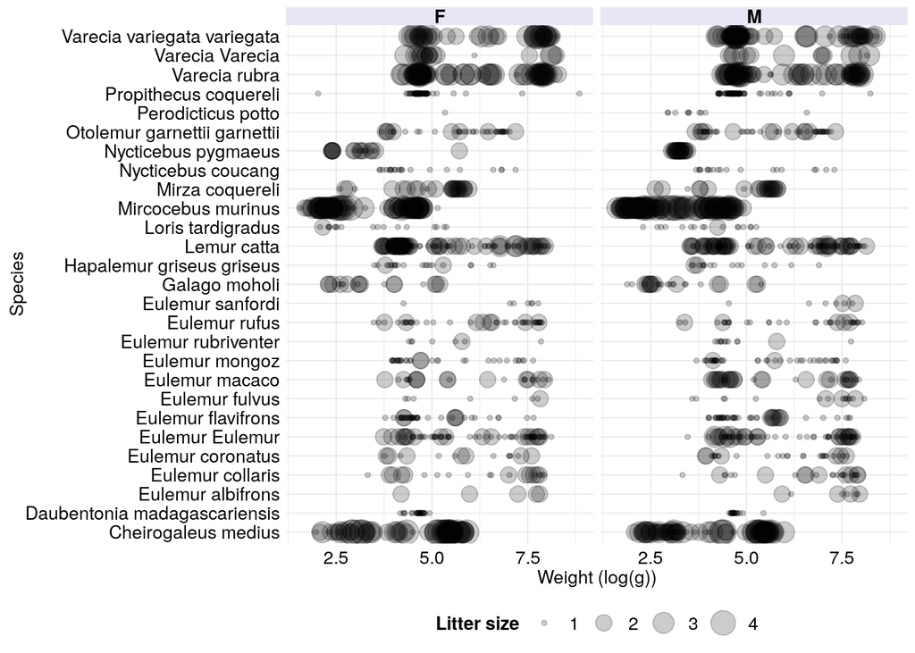

```r
litterweight_df  %>%
  dplyr::filter(sex != "ND") %>%
  ggplot(aes(x = log(weight), y = species))+
  geom_point(aes(size = litter_size), alpha = 0.2) +
  facet_wrap(~sex, ncol = 2) +
  labs(x = "Weight (log(g))", y = "Species", size = "Litter size") +
  theme_lemurs()
```

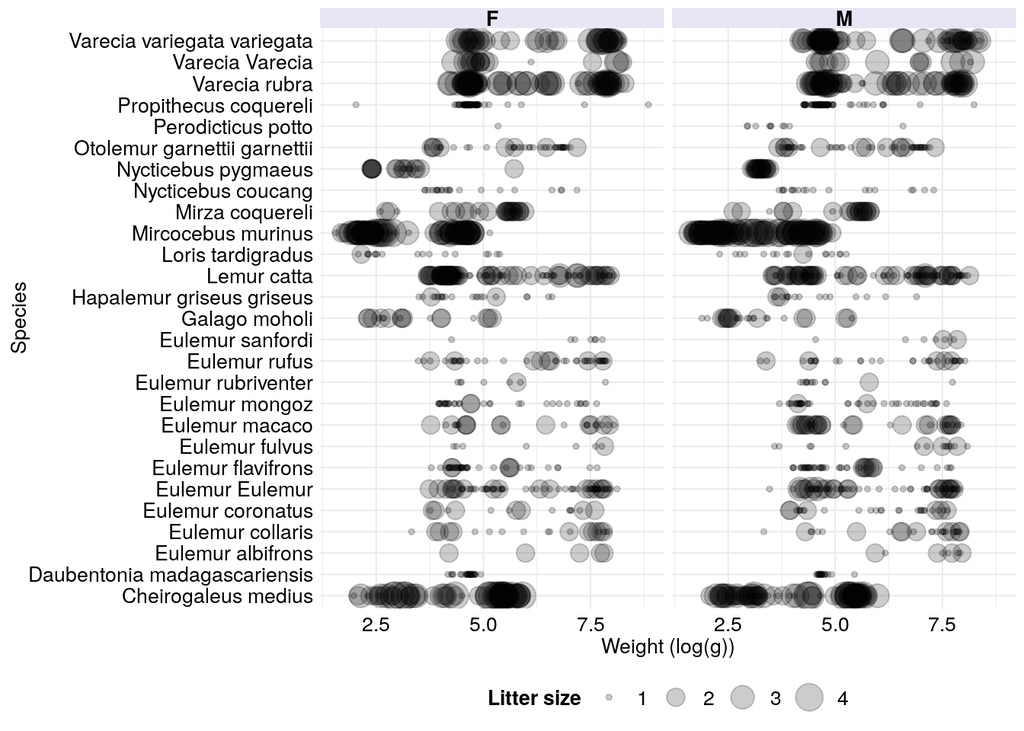

```r
litterweight_df  %>%
  dplyr::filter(sex != "ND") %>%
  ggplot(aes(x = log(weight), y = species))+
  geom_point(aes(size = litter_size), alpha = 0.2) +
  facet_wrap(~sex, ncol = 2) +
  labs(x = "Weight (log(g))", y = "Species", size = "Litter size") +
  theme_lemurs()
```

# Next steps

Try exploring the `flights` data set, included with the basic R download.

```r
install.packages("nycfilghts13")
library(nycflights13)
```